# Reproducible Research: Peer Assessment 1

## Loading and preprocessing the data

1. Load the data

```r
activity <- read.csv("activity.csv")
```

2. Process/transform the data (if necessary) into a format suitable for your analysis

The 5-minute interval was presented as a combination of hour and time (eg, 0 means 00:00 or the 1st 5 minutes of the 1st hour, 1115 means 11:15 or the 4th 5 minutes of the 12th hour). The interval is therefore changed into the number of minutes elapsed since the time 0.

```r
minute <- activity$interval %% 100
hour <- (activity$interval-minute)/100
activity$time <- hour*60 + minute
```

## What is mean total number of steps taken per day?

1. Calculate the total number of steps taken per day

```r
steps.per.day <- tapply(activity$steps, activity$date, sum, na.rm = FALSE)
```

2. Make a histogram of the total number of steps taken each day

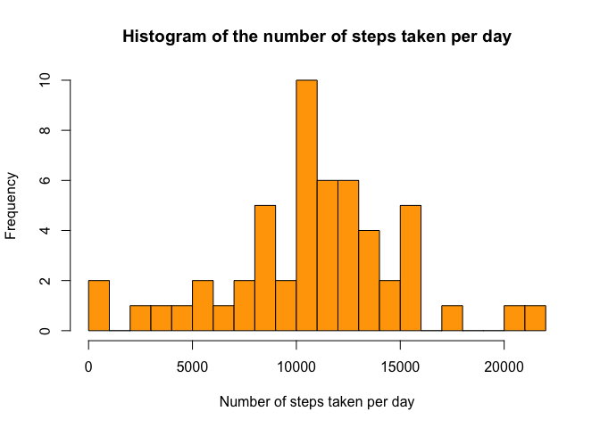

```r
hist(steps.per.day, breaks = 25, col = "orange",
     main = "Histogram of the number of steps taken per day",
     xlab = "Number of steps taken per day")
```

3. Calculate and report the mean and median for the total number of steps taken per day

The mean is

```r
mean(steps.per.day, na.rm = TRUE)
```

```
## [1] 10766.19
```

and the median is

```r
median(steps.per.day, na.rm = TRUE)
```

```
## [1] 10765
```

## What is the average daily activity pattern?

1. Make a time series plot of the 5-minute interval (x-axis) and the average number of steps taken, averaged across all days (y-axis)

```r
library(dplyr)
```

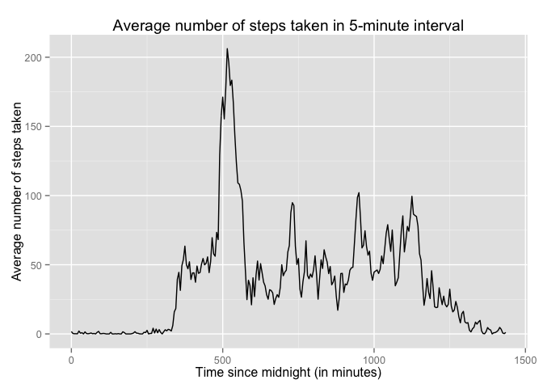

```r
activity.summary <- summarise(group_by(activity,time),
                              steps=mean(steps, na.rm=TRUE))
library(ggplot2)
ggplot(data=activity.summary, aes(x=time, y=steps)) +
    geom_line() +
    labs(x="Time since midnight (in minutes)") +
    labs(y="Average number of steps taken") +
    labs(title="Average number of steps taken in 5-minute interval")
```

2. Which 5-minute interval, on average across all the days in the dataset, contains the maximum number of steps?

The 5-minute interval with the maximum number of steps is the interval

```r
steps.per.5minutes <- tapply(activity$steps, activity$time, mean, na.rm = TRUE)
max.steps <- max(steps.per.5minutes)
max.interval <- unique(activity$interval[steps.per.5minutes==max.steps])
max.interval
```

```
## [1] 835
```

that is, the one that starts at

```r
(max.interval-max.interval %% 100)/100
```

```
## [1] 8
```

o’clock and

```r
max.interval %% 100
```

```
## [1] 35
```

minutes.

## Imputing missing values

1. Calculate and report the total number of missing values in the dataset

There are

```r
sum(is.na(activity))
```

```
## [1] 2304
```

cases with missing values.

2. Devise a strategy for filling in all of the missing values in the dataset

A missing value from a 5-minute interval was replaced by the mean of the same 5-minute interval (averaged over all the days in the dataset).

```r
new.steps <- rep(0, times=nrow(activity))
mean.steps <- rep(steps.per.5minutes, times=61)
for (i in 1:nrow(activity)) {
    if (is.na(activity$steps[i]) == TRUE) {
        new.steps[i] <- mean.steps[i]
    }
    else {
        new.steps[i] <- activity$steps[i]
    }
}
```

3. Create a new dataset that is equal to the original dataset but with the missing data filled in

```r
new.activity <- data.frame(steps=new.steps, date=as.Date(activity$date),
                      interval=activity$interval)
head(new.activity)
```

```
##       steps       date interval
## 1 1.7169811 2012-10-01        0
## 2 0.3396226 2012-10-01        5
## 3 0.1320755 2012-10-01       10
## 4 0.1509434 2012-10-01       15
## 5 0.0754717 2012-10-01       20
## 6 2.0943396 2012-10-01       25
```

- Make a histogram of the total number of steps taken each day and calculate and report the mean and median total number of steps taken per day.

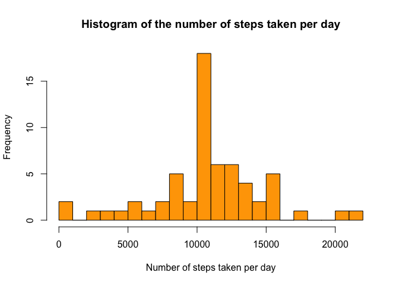

```r
new.steps.per.day <- tapply(new.activity$steps, new.activity$date, sum,
                            na.rm=FALSE)
hist(new.steps.per.day, breaks = 25, col = "orange",
     main = "Histogram of the number of steps taken per day",
     xlab = "Number of steps taken per day")
```

The new mean is

```r
mean(new.steps.per.day, na.rm=TRUE)
```

```
## [1] 10766.19
```

and the new median is

```r
median(new.steps.per.day, na.rm=TRUE)
```

```
## [1] 10766.19
```

- Do these values differ from the estimates from the first part of the assignment?

The mean values are exactly the same.

```r
t.test(steps.per.day, new.steps.per.day)
```

```
##
##  Welch Two Sample t-test
##
## data:  steps.per.day and new.steps.per.day
## t = 0, df = 107.145, p-value = 1
## alternative hypothesis: true difference in means is not equal to 0
## 95 percent confidence interval:
##  -1539.144  1539.144
## sample estimates:
## mean of x mean of y
##  10766.19  10766.19
```

## Are there differences in activity patterns between weekdays and weekends?

1. Create a new factor variable in the dataset with two levels - “weekday” and “weekend” indicating whether a given date is a weekday or weekend day.

```r
day <- rep("", times=nrow(new.activity))
for (i in 1:nrow(new.activity)) {
    weekday <- weekdays(new.activity$date[i])
    if (weekday == "Saturday"| weekday == "Sunday") {
        day[i] = "weekend"
    }
    else {
        day[i] = "weekday"
    }
}
new.activity <- cbind(new.activity, time=activity$time, day=day)
```

2. Make a panel plot containing a time series plot of the 5-minute interval (x-axis) and the average number of steps taken, averaged across all weekdays days or weekend days (y-axis).

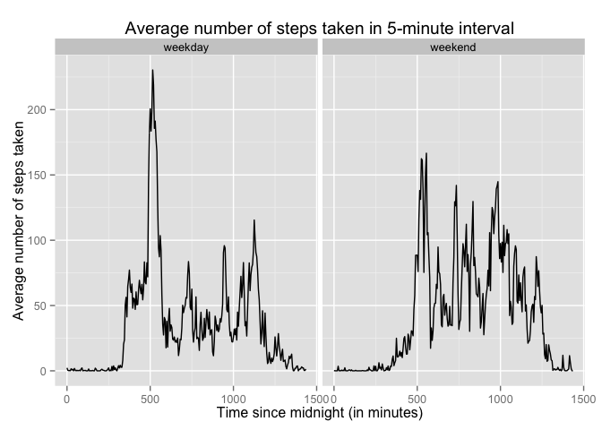

```r
new.activity.summary <- summarise(group_by(new.activity,day,time),
                                  steps=mean(steps))
library(ggplot2)
ggplot(data=new.activity.summary, aes(x=time, y=steps)) +
    geom_line() + facet_grid(. ~ day) +
    labs(x="Time since midnight (in minutes)") +
    labs(y="Average number of steps taken") +
    labs(title="Average number of steps taken in 5-minute interval")
```